# Test d hypoth??se : un exemple (suite)

Lucas Mello Schnorr, Jean-Marc Vincent

March 14, 2017

### Pr??sentation du paradoxe

?? la cour de Florence, de nombreux jeux de soci??t?? ??taient alors pratiqu??s. Parmi ceux-ci, l???un faisait intervenir la somme des num??ros sortis lors du lancer de trois d??s. Le Duc de Toscane, qui avait sans doute observ?? un grand nombre de parties de ce jeu, avait constat?? que la somme 10 ??tait obtenue l??g??rement plus souvent que la somme 9. Le paradoxe, que le Duc avait expos?? ?? Galil??e, r??side dans le fait qu???il y a autant de fa??ons d?????crire 10 que 9 comme sommes de trois entiers compris entre 1 et 6

En effet, il y a 6 mani??res d’??crire 9 comme somme de 3 d??s: 1+2+6, 1+3+5, 1+4+4, 2+2+5, 2+3+4, 3+3+3 et il y a 6 mani??res d’??crire 10 : 1+3+6, 1+4+5, 2+2+6, 2+3+5, 2+4+4, 3+3+4

### Exp??rimentation

Construction de l’environnement de simulation:

```r
# package
library(dplyr);
```

```r
library(ggplot2);
library(gridExtra);
```

*g??n??rateur de d?? ?? $k$ faces*: les appels successifs ?? la foncion Dice(faces,n) sont mod??lis??s par une s??quence de $n$ d variables al??atoires ind??pendantes de m??me loi uniforme dans $\{1,\cdots, faces\}$.

```r
dice <- function(faces = 6, n = 100)
{
  sample(x = seq(from = 1, to = faces, by = 1), size=n, replace=TRUE);
}

# g??n??re 10 tirages d'un d?? ?? 6 faces
dice(6,10)
```

```
##  [1] 3 2 6 5 2 1 5 1 5 5
```

*Exp??rience du Duc de Toscane* : on g??n??re un ??chantillon de $n$ observations de jet??s de $3$ d??s

```r
experiment <- function (faces = 6, n = 100)
{
  set.seed(42)
  dice1 <- dice(faces, n);
  dice2 <- dice(faces, n);
  dice3 <- dice(faces, n);

  data.frame(Dice1 = dice1,
             Dice2 = dice2,
             Dice3 = dice3);
}
# g??n??re une exp??rience de 5 tirages de 3 d??s ?? 6 faces
experiment(6,5)
```

```
##   Dice1 Dice2 Dice3
## 1     6     4     3
## 2     6     5     5
## 3     2     1     6
## 4     5     4     2
## 5     4     5     3
```

### Somme de $3$ d??s, r??partition

On g??n??re une exp??rience et on calcule la somme des $3$ d??s :

```r
experiment(6,1000) %>%
  mutate(Sum = Dice1 + Dice2 + Dice3) %>%
  group_by(Sum) %>%
  summarize(N=n());
```

```
## # A tibble: 16 x 2
##      Sum     N
##    <dbl> <int>
##  1     3     6
##  2     4    20
##  3     5    24
##  4     6    44
##  5     7    78
##  6     8    99
##  7     9   124
##  8    10   122
##  9    11   114
## 10    12   105
## 11    13    99
## 12    14    79
## 13    15    38
## 14    16    27
## 15    17    14
## 16    18     7
```

```r
# calcule le nombre d'occurrences de chaque valeur possible de somme
```

Visualisation de la distribution empirique des probabilit??s Faire l’essai avec plusieurs tailles d’??chantillon, que peut-on remarquer ?

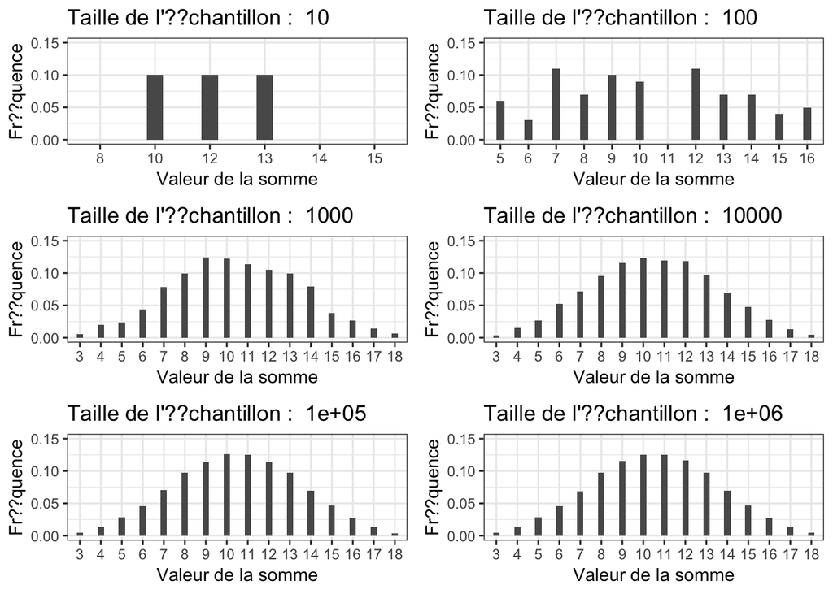

```r
Toscane <- function(faces =6, n = 100)
{
  experiment(faces,n) %>%
    mutate(Sum = Dice1 + Dice2 + Dice3) %>%
    ggplot(aes(x=as.factor(Sum))) +
    geom_bar(aes(y = (..count..)/sum(..count..)), width = .3) +
    xlab("Valeur de la somme")+ylab ("Fr??quence") +
    ggtitle(paste("Taille de l'??chantillon : ",n)) +
    # ?? modifier pour adapter et utiliser les facets
    ylim (0, 0.15) +
    theme_bw()
}
list(10,100,1000,10000,100000,1000000) %>%
lapply(function(taille) {
  Toscane( n = taille )
}) %>%
grid.arrange(ncol = 2,grobs=.);
```

### Calcul de l’erreur sur l’estimation #### D??pendance de la taille de l’??chantillon

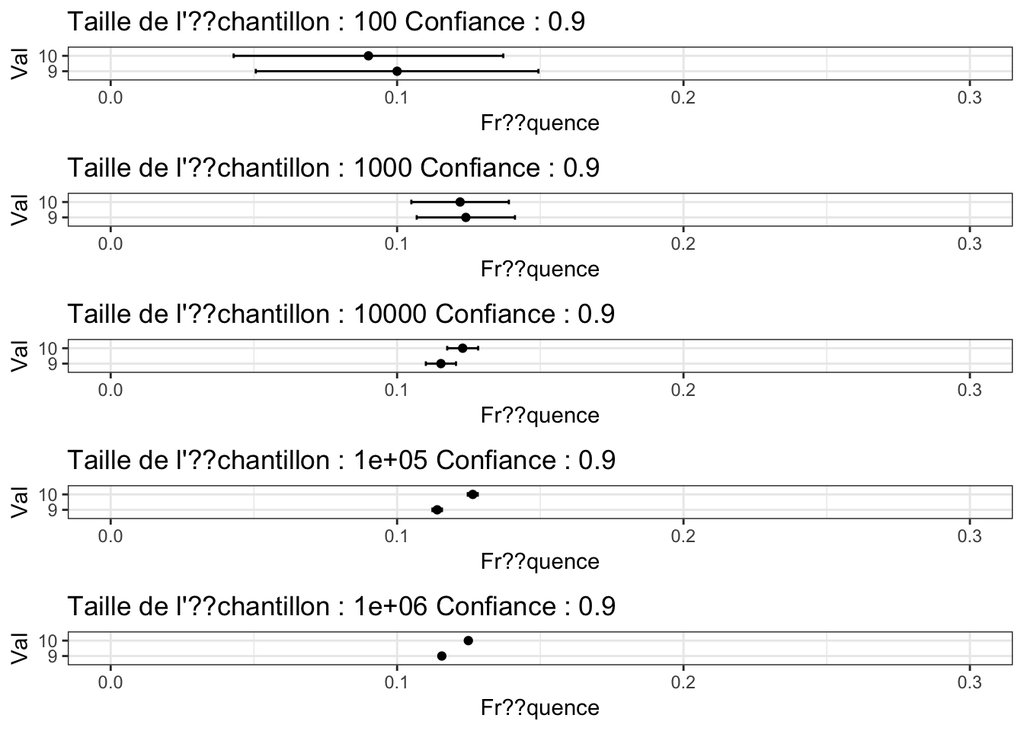

```r
Toscane_9_10_erreur <-function(faces = 6, n = 471, Confiance = 0.95 )
{
  Phi_alpha= qnorm(1-(1-Confiance)/2) ;

  experiment(faces,n) %>%
    mutate(Sum = Dice1 + Dice2 + Dice3,Taille=n()) %>%
    group_by(Sum,Taille) %>%
    summarize(N=n()) %>%
    mutate(Freq=N/Taille) %>%
    mutate(Ecart_type_Estime=sqrt(Freq*(1-Freq)),
         Erreur=Phi_alpha*Ecart_type_Estime/sqrt(Taille)) %>%
    filter((Sum == 9)|(Sum == 10))%>%
    ggplot(aes(x=Freq,xmin=Freq-Erreur,xmax=Freq+Erreur,y=as.factor(Sum))) +
    geom_point()+
    geom_errorbarh(height=.3)+
    xlab("Fr??quence")+ylab ("Val") +
    xlim(0,0.3)+
    labs(title = paste("Taille de l'??chantillon :",n,"Confiance :",Confiance)  )+
#    ylim (, ) +
    theme_bw()
}

list(100,1000,10000,100000,1000000) %>%
lapply(function(taille) {
  Toscane_9_10_erreur( n = taille , Confiance = 0.90)
}) %>%
grid.arrange(ncol = 1,grobs=.);
```

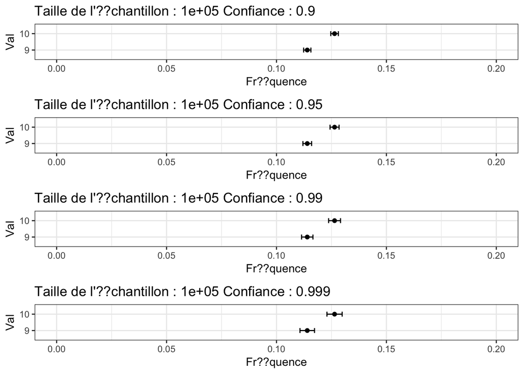

```r
Toscane_9_10_erreur <-function(faces = 6, n = 1000, Confiance = 0.95 )
{
  Phi_alpha= qnorm(1-(1-Confiance)/2) ;

  experiment(faces,n) %>%
    mutate(Sum = Dice1 + Dice2 + Dice3,Taille=n()) %>%
    group_by(Sum,Taille) %>%
    summarize(N=n()) %>%
    mutate(Freq=N/Taille) %>%
    mutate(Ecart_type_Estime=sqrt(Freq*(1-Freq)),
         Erreur=Phi_alpha*Ecart_type_Estime/sqrt(Taille)) %>%
    filter((Sum == 9)|(Sum == 10))%>%
    ggplot(aes(x=Freq,xmin=Freq-Erreur,xmax=Freq+Erreur,y=as.factor(Sum))) +
    geom_point()+
    geom_errorbarh(height=.3)+
    xlab("Fr??quence")+ylab ("Val") +
    xlim(0,0.2)+
    labs(title = paste("Taille de l'??chantillon :",n,"Confiance :",Confiance)  )+
#    ylim (, ) +
    theme_bw()
}
list(0.9,0.95,0.99,0.999) %>%
lapply(function(Param_Confiance) {
  Toscane_9_10_erreur( n = 100000 , Confiance = Param_Confiance)
}) %>%
grid.arrange(ncol = 1,grobs=.);
```

### Un peu de th??orie

Dans le probl??me du Duc de Toscane, on peut mod??liser le probl??me et calculer les diff??rentes probabilit??s.

#### Mod??le

On mod??lise le probl??me en repr??sentant les lancers des 3 d??s par 3 variables al??atoires $X_1,X_2,X_3$, ind??pendantes et identiquement distribu??es sur $\{1,2\cdots,6\}$. C’est ?? dire que pour $0\leq k \leq 6$
$$\mathbb{P}(X_i=k)=\frac 16 \text{ pour } i\in\{1,2,3\} ;$$
et que pour $0\leq k_1,k_2,k_3 \leq 6$
$$\mathbb{P}(X_1=k_1,X_2=k_2,X_3=k_3)= \mathbb{P}(X_1=k_1)\mathbb{P}(X_2=k_2)\mathbb{P}(X_3=k_3)=\frac 1 {6^3}.$$
On obtient ainsi la loi uniforme sur l’ensemble $\{1,2,3,4,5,6\}^3$.

On note $S= X_1+X_2+X_3$ la variable al??atoire repr??sentant la somme des valeurs des 3 d??s. Pour cela on peut regarder l’ensemble des triplets choisis dans $\{1,2,3,4,5,6\}^3$ et compter le nombre de triplets de somme $k$ avec $0\leq k\leq 18$.

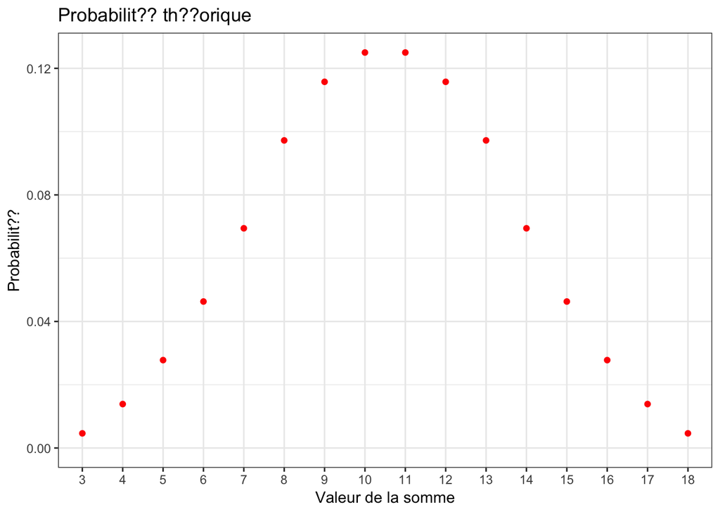

```r
faces = 6 ;

d = data.frame();
for (de1 in seq(1,faces)){
 for (de2 in seq(1,faces)){
   for (de3 in seq(1,faces)){
     d <<- rbind(d, data.frame(Dice1 = de1, Dice2 = de2, Dice3 = de3));
   }
 }
}

d %>%
 mutate(Sum=Dice1+Dice2+Dice3, Total=n()) %>%
 group_by(Sum, Total) %>%
 summarize(N = n()) %>%
 ungroup () %>%
 mutate(P = N/sum(N)) -> d_theorique;

ggplot(data=d_theorique, aes(x=as.factor(Sum), y = P)) +
    geom_point(color = "red") +
    xlab("Valeur de la somme")+ylab ("Probabilit??") +
    ggtitle("Probabilit?? th??orique") +
    # ?? modifier pour adapter et utiliser les facets
    ylim (0, NA) +
    theme_bw()
```

On reprend les exp??riences pr??c??dentes et on prend les histogrammes pour diff??rentes tailles d’??chantillons

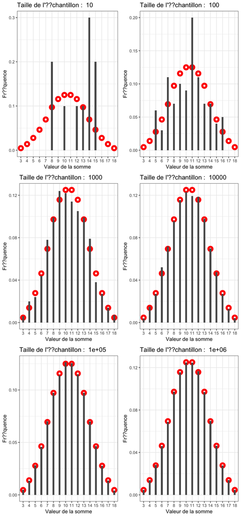

```r
Toscane_avec_theorie <- function(faces =6, n = 100)
{
  experiment(faces,n) %>%
    mutate(Sum = Dice1 + Dice2 + Dice3) %>%
    ggplot(aes(x=as.factor(Sum))) +
    geom_point(data=d_theorique, aes(x=as.factor(Sum), y = P), shape = 21, colour = "red", fill = "white", size = 2, stroke = 3)+
    geom_bar(aes(y = (..count..)/sum(..count..)), width = .3) +
    xlab("Valeur de la somme")+ylab ("Fr??quence") +
    ggtitle(paste("Taille de l'??chantillon : ",n)) +
    # ?? modifier pour adapter et utiliser les facets
    ylim (0, NA) +
    theme_bw()
}

list(10,100,1000,10000,100000,1000000) %>%
lapply(function(taille) {
  Toscane_avec_theorie( n = taille )
}) %>%
grid.arrange(ncol = 2,grobs=.)
```

### Que peut-on conclure ?

L’erreur m??thodologique dans l’??nonc?? propos?? par le Duc de Toscane est de supposer que toute configuration de valeurs de d??s, ici un ensemble de 3 d??s, a la m??me probabilit??. Dans notre cas on peut calculer toutes les combinaisons (exercice : le faire et en triant avoir le nombre d’ensembles de 3 valeurs et leur somme).

En fait, les ensembles de 3 valeurs n’ont pas la m??me probabilit?? d’apparition:

9 comme somme de 3 d??s : 1+2+6 (6 triplets), 1+3+5 (6), 1+4+4 (3), 2+2+5 (3), 2+3+4 (6), 3+3+3 (1)

10 comme somme de 3 d??s : 1+3+6 (6), 1+4+5 (6), 2+2+6 (3), 2+3+5 (6), 2+4+4 (3), 3+3+4 (3)

Par exemple 1+2+6 s’obtient avec les triplets (1,2,6) (1,6,2) (2,1,6) (2,6,1) (6,1,2) (6,2,1)

La probabilit?? d’observer 9 (respectivement 10) est $p_9= \frac {25}{6^3}=0.1157$ (respectivement $p_{10}= \frac {27}{6^3}=0.1250$). On observe donc que $p_9 < p_{10}$, comme suppos?? par le Duc de Toscane. La diff??rence de ces deux probabilit??s est de $\frac 2 {6^3}=0.0093\simeq 1\%$, ce qui est faible.

Le Duc explique sa conviction par l’observation, et certainement le relev?? d’un tr??s grand nombre de parties. Or d’apr??s les intervalles de confiance calcul??s ci-dessus il faut une taille d’??chantillon de l’ordre de $100000$ pour avoir un intervalle de confiance autour de chaque valeur estim??e qui permette de s??parer $p_9$ et $p_10$ avec une confiance de 95%.

Ayant r??alis?? autant d’observations, le Duc n’aurait pas manqu?? d’observer les fluctuations “naturelles” dans les estimateurs des probabilit??s $P_9$ et $p_10$.

Enfin, il reste ?? supposer que les d??s utilis??s lors des 100.000 lancers ??taient identiques, non biais??s, et que la probabilit??s de chaque face soit $\frac 16$ avec une erreur largement inf??rieure ?? $1% (actuellement fabriquer des d??s non-biais??s est un probl??me technologiquement tr??s difficile). Mat??riellement il ??tait donc tr??s difficile de r??pondre exp??rimentalement ?? cette question.

Comment interpr??ter cette situation ? On peut resituer le contexte, au XVIi??me si??cle, les math??maticiens ??tablissaient leur r??putation en se lan??ant des d??fis, par exemple Girolamo Cardano (1501 - 1576) a tenu sa m??thode de r??solution d’??quations de 3i??me degr?? (de la forme $x^3+ax^2+bx+c=0$) secr??te afin de pouvoir r??soudre des probl??mes que d’autres math??maticiens ??taient incapable de r??soudre (Lire par exemple *La formule secr??te - le duel math??matique qui enflamma l’Italie de la Renaissance de Fabio Toscano, edition Belin 2011*). On pourrait donc penser que le Duc de Toscane d??fiait Galil??e sur le terrain de l’exp??rimentation, en sachant pertinemment le r??sultat th??orique, n’ayant pas les outils de statistique qui appara??tront plus tard au XVIII$^\text{i??me}$ si??cle (loi des erreurs de Moivre et Laplace) puis au XVIII$^\text{i??me}$ avec Gauss.

On pourrait ??galement penser que Galil??e, utilisant ce paradoxe comme introduction p??dagogique, voulait donner un caract??re *aristocratique* ?? la question et ainsi donner plus de force ?? sa d??monstration de l’int??r??t du calcul analytique au d??pend de l’approche purement exp??rimentale. Nous laisserons les historiens des sciences d??battre de cette question.